# Линейная модель средней стоимости домов в Бостоне

### 2.2 Отбор предикторов по значимости

Для отбора предикторов будем рассматривать их значимость при помощи F-теста и функции *drop1*.

```r
drop1(model_6, test = "F")
```

```
## Single term deletions
##
## Model:
## medv ~ crim + zn + chas + rm + age + ptratio + black + dis +
##     lstat
##         Df Sum of Sq    RSS     AIC  F value    Pr(>F)
## <none>               142.30 -621.91
## crim     1     1.730 144.03 -617.79   6.0312  0.014397 *
## zn       1     2.411 144.71 -615.41   8.4032  0.003912 **
## chas     1     2.870 145.17 -613.80  10.0035  0.001658 **
## rm       1    31.530 173.83 -522.64 109.8992 < 2.2e-16 ***
## age      1     0.926 143.23 -620.63   3.2264  0.073068 .
## ptratio  1    11.704 154.00 -583.91  40.7946 3.896e-10 ***
## black    1     5.090 147.39 -606.13  17.7399 3.008e-05 ***
## dis      1     9.574 151.88 -590.96  33.3710 1.346e-08 ***
## lstat    1    32.098 174.40 -520.99 111.8787 < 2.2e-16 ***
## ---
## Signif. codes:  0 '***' 0.001 '**' 0.01 '*' 0.05 '.' 0.1 ' ' 1
```

Из результата работы функции можно понять, что удаление предиктора *age* незначимо влияет на объясняемую изменчивость модели. Удалим его и повторим процедуру.

```r
model_7 <- update(model_6, .~. - age)
drop1(model_7, test = "F")
```

```
## Single term deletions
##
## Model:
## medv ~ crim + zn + chas + rm + ptratio + black + dis + lstat
##         Df Sum of Sq    RSS     AIC  F value    Pr(>F)
## <none>               143.23 -620.63
## crim     1     1.722 144.95 -616.58   5.9741  0.014864 *
## zn       1     2.848 146.07 -612.66   9.8831  0.001768 **
## chas     1     2.672 145.90 -613.28   9.2715  0.002451 **
## rm       1    30.605 173.83 -524.64 106.2001 < 2.2e-16 ***
## ptratio  1    11.818 155.04 -582.51  41.0095 3.514e-10 ***
## black    1     4.866 148.09 -605.72  16.8850 4.645e-05 ***
## dis      1     9.052 152.28 -591.62  31.4106 3.466e-08 ***
## lstat    1    43.627 186.85 -488.08 151.3856 < 2.2e-16 ***
## ---
## Signif. codes:  0 '***' 0.001 '**' 0.01 '*' 0.05 '.' 0.1 ' ' 1
```

```r
model_8 <- update(model_7, .~. - crim)
drop1(model_8, test = "F")
```

```
## Single term deletions
##
## Model:
## medv ~ zn + chas + rm + ptratio + black + dis + lstat
##         Df Sum of Sq    RSS     AIC  F value    Pr(>F)
## <none>               144.95 -616.58
## zn       1     2.254 147.20 -610.77   7.7432  0.005596 **
## chas     1     2.854 147.80 -608.72   9.8054  0.001842 **
## rm       1    30.129 175.08 -523.02 103.5157 < 2.2e-16 ***
## ptratio  1    13.855 158.80 -572.39  47.6009 1.593e-11 ***
## black    1     6.444 151.39 -596.57  22.1408 3.287e-06 ***
## dis      1     7.747 152.70 -592.23  26.6181 3.586e-07 ***
## lstat    1    50.175 195.12 -468.17 172.3867 < 2.2e-16 ***
## ---
## Signif. codes:  0 '***' 0.001 '**' 0.01 '*' 0.05 '.' 0.1 ' ' 1
```

```r
model_9 <- update(model_8, .~. - zn)
drop1(model_9, test = "F")
```

```
## Single term deletions
##
## Model:
## medv ~ chas + rm + ptratio + black + dis + lstat
##         Df Sum of Sq    RSS     AIC  F value    Pr(>F)
## <none>               147.20 -610.77
## chas     1     2.735 149.94 -603.46   9.2712  0.002451 **
## rm       1    33.486 180.69 -509.06 113.5155 < 2.2e-16 ***
## ptratio  1    18.649 165.85 -552.42  63.2168 1.247e-14 ***
## black    1     6.031 153.23 -592.46  20.4454 7.673e-06 ***
## dis      1     5.536 152.74 -594.09  18.7672 1.786e-05 ***
## lstat    1    49.276 196.48 -466.67 167.0400 < 2.2e-16 ***
## ---
## Signif. codes:  0 '***' 0.001 '**' 0.01 '*' 0.05 '.' 0.1 ' ' 1
```

Больше не осталось предикторов, удаление которых было бы незначимо для данной модели.

```r
summary(model_9)
```

```
##
## Call:
## lm(formula = medv ~ chas + rm + ptratio + black + dis + lstat,
##     data = data)
##
## Residuals:
##      Min       1Q   Median       3Q      Max
## -2.00571 -0.29146 -0.07414  0.18195  3.01388
##
## Coefficients:
##             Estimate Std. Error t value Pr(>|t|)
## (Intercept) -0.43102    0.09387  -4.592 5.57e-06 ***
## chasFar      0.29591    0.09718   3.045  0.00245 **
## rm           0.33858    0.03178  10.654  < 2e-16 ***
## ptratio     -0.21276    0.02676  -7.951 1.25e-14 ***
## black1       0.44388    0.09817   4.522 7.67e-06 ***
## dis         -0.12422    0.02868  -4.332 1.79e-05 ***
## lstat       -0.47092    0.03644 -12.924  < 2e-16 ***
## ---
## Signif. codes:  0 '***' 0.001 '**' 0.01 '*' 0.05 '.' 0.1 ' ' 1
##
## Residual standard error: 0.5431 on 499 degrees of freedom
## Multiple R-squared:  0.7085, Adjusted R-squared:  0.705
## F-statistic: 202.2 on 6 and 499 DF,  p-value: < 2.2e-16
```

### 2.3 Диагностика редуцированной модели

Построим график остатков полученной модели:

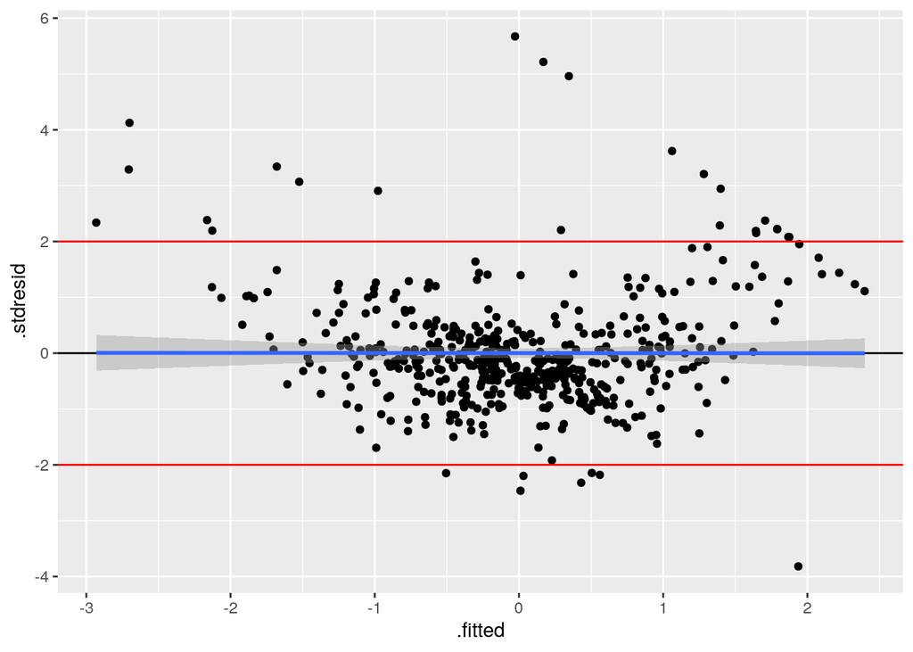

```r
model_9_diag <- data.frame(fortify(model_9), data[])

gg_resid <- ggplot(data = model_9_diag, aes(x = .fitted, y = .stdresid)) +
  geom_point() +
  geom_hline(yintercept = 0) +
  geom_smooth(method = "lm") +
  geom_hline(yintercept = 2, color = "red") +
  geom_hline(yintercept = -2, color = "red")
gg_resid
```

Во-первых, сразу, как и в случае полной модели, можно сказать, что взаимосвязь **нелинейная**. Во-вторых, остатки **гетероскедастичны**:

```r
bptest(model_9)
```

```
##
##  studentized Breusch-Pagan test
##
## data:  model_9
## BP = 36.971, df = 6, p-value = 1.784e-06
```

В-третьих, мы также видим, что наблюдения на самом деле **не являются независимыми**.

Построим график остатков Кука:

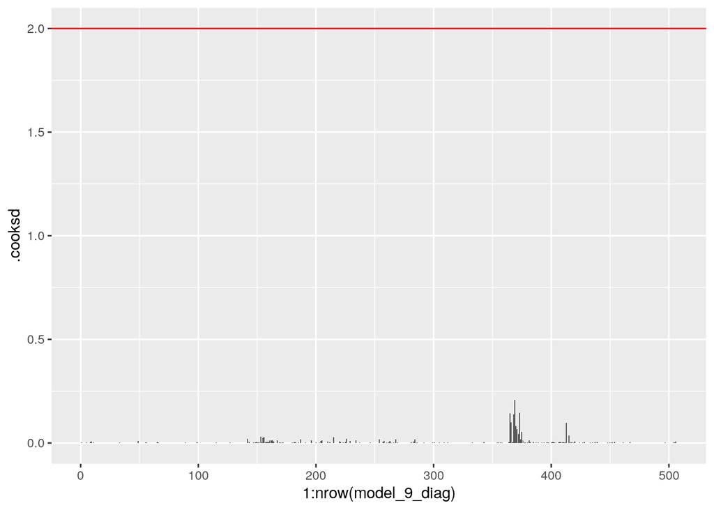

```r
ggplot(model_9_diag, aes(x = 1:nrow(model_9_diag), y = .cooksd)) +
  geom_bar(stat = "identity") +
  geom_hline(yintercept = 2, color = "red")
```

По этому графику можно сделать вывод, что **влиятельных наблюдений в нашем датасете нет**.

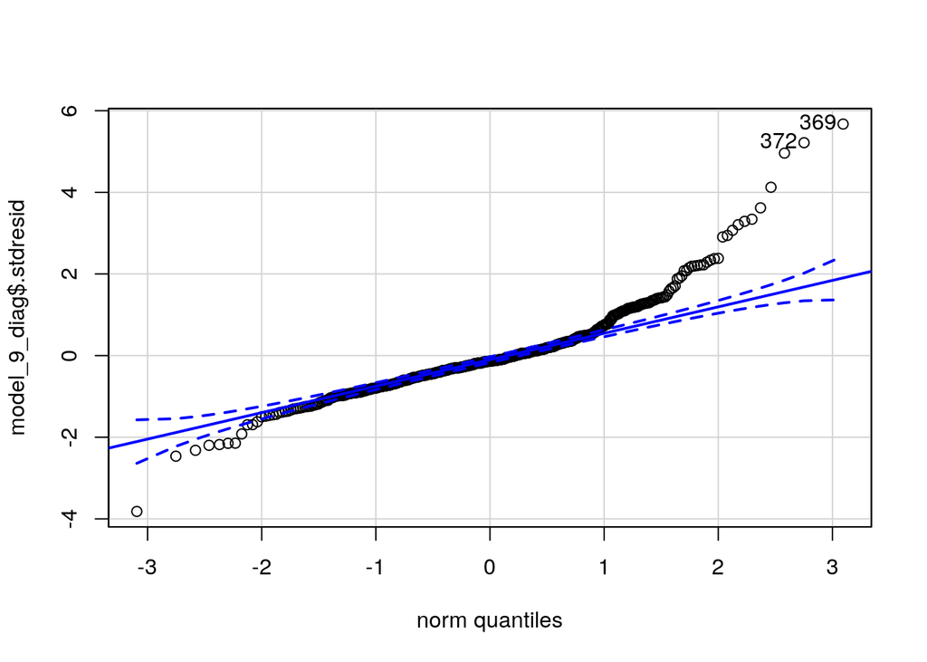

```
## [1] 369 372
```

```r
qqPlot(model_9_diag$.stdresid)
```

Так как точки не легли на одну прямую, то это означает, что остатки **не подчиняются нормальному распределению** (есть хвосты), а **дисперсия непостоянна**.

### 2.4 Обсуждение

В целом, наша модель не улучшилась по сравнению с полной по показателю коэффициента детерминации, но зато критерий F-статистики вырос, а самое главное, анализировать такую модель стало гораздо проще: предикторы практически не коррелируют, а также нет никаких незначимых предикторов.

```r
summary(model_9)
```

```
##
## Call:
## lm(formula = medv ~ chas + rm + ptratio + black + dis + lstat,
##     data = data)
##
## Residuals:
##      Min       1Q   Median       3Q      Max
## -2.00571 -0.29146 -0.07414  0.18195  3.01388
##
## Coefficients:
##             Estimate Std. Error t value Pr(>|t|)
## (Intercept) -0.43102    0.09387  -4.592 5.57e-06 ***
## chasFar      0.29591    0.09718   3.045  0.00245 **
## rm           0.33858    0.03178  10.654  < 2e-16 ***
## ptratio     -0.21276    0.02676  -7.951 1.25e-14 ***
## black1       0.44388    0.09817   4.522 7.67e-06 ***
## dis         -0.12422    0.02868  -4.332 1.79e-05 ***
## lstat       -0.47092    0.03644 -12.924  < 2e-16 ***
## ---
## Signif. codes:  0 '***' 0.001 '**' 0.01 '*' 0.05 '.' 0.1 ' ' 1
##
## Residual standard error: 0.5431 on 499 degrees of freedom
## Multiple R-squared:  0.7085, Adjusted R-squared:  0.705
## F-statistic: 202.2 on 6 and 499 DF,  p-value: < 2.2e-16
```

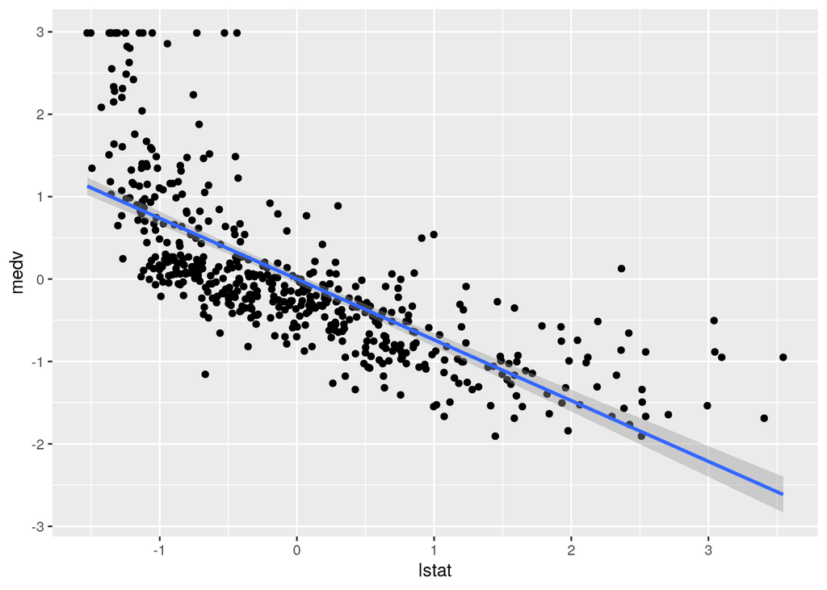

```r
ggplot(data, aes(x = lstat, y = medv)) +
  geom_point() +
  geom_smooth(method = "lm")
```

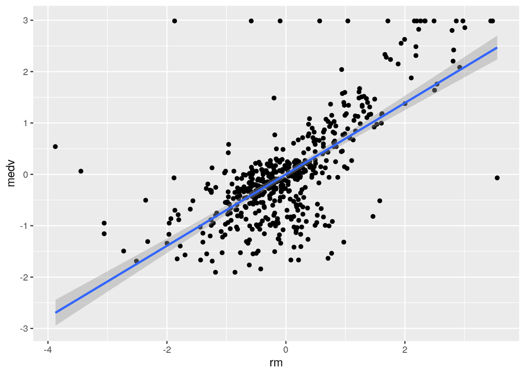

```r
ggplot(data, aes(x = rm, y = medv)) +
  geom_point() +
  geom_smooth(method = "lm")
```

### 3. Построение новой модели

```r
data$lstat2 <- 1 / (data$lstat)
model_10 <- lm(medv ~ chas + rm + ptratio + black + dis + lstat2, data)
summary(model_9)
```

```
##
## Call:
## lm(formula = medv ~ chas + rm + ptratio + black + dis + lstat,
##     data = data)
##
## Residuals:
##      Min       1Q   Median       3Q      Max
## -2.00571 -0.29146 -0.07414  0.18195  3.01388
##
## Coefficients:
##             Estimate Std. Error t value Pr(>|t|)
## (Intercept) -0.43102    0.09387  -4.592 5.57e-06 ***
## chasFar      0.29591    0.09718   3.045  0.00245 **
## rm           0.33858    0.03178  10.654  < 2e-16 ***
## ptratio     -0.21276    0.02676  -7.951 1.25e-14 ***
## black1       0.44388    0.09817   4.522 7.67e-06 ***
## dis         -0.12422    0.02868  -4.332 1.79e-05 ***
## lstat       -0.47092    0.03644 -12.924  < 2e-16 ***
## ---
## Signif. codes:  0 '***' 0.001 '**' 0.01 '*' 0.05 '.' 0.1 ' ' 1
##
## Residual standard error: 0.5431 on 499 degrees of freedom
## Multiple R-squared:  0.7085, Adjusted R-squared:  0.705
## F-statistic: 202.2 on 6 and 499 DF,  p-value: < 2.2e-16
```

```r
summary(model_10)
```

```
##
## Call:
## lm(formula = medv ~ chas + rm + ptratio + black + dis + lstat2,
##     data = data)
##
## Residuals:
##     Min      1Q  Median      3Q     Max
## -2.2369 -0.3204 -0.0216  0.2422  4.2678
##
## Coefficients:
##               Estimate Std. Error t value Pr(>|t|)
## (Intercept) -0.7207355  0.1052888  -6.845 2.25e-11 ***
## chasFar      0.3379699  0.1121997   3.012  0.00273 **
## rm           0.5720963  0.0302358  18.921  < 2e-16 ***
## ptratio     -0.2546841  0.0307217  -8.290 1.06e-15 ***
## black1       0.7541377  0.1099489   6.859 2.06e-11 ***
## dis          0.0336365  0.0300217   1.120  0.26308
## lstat2      -0.0003040  0.0007499  -0.405  0.68537
## ---
## Signif. codes:  0 '***' 0.001 '**' 0.01 '*' 0.05 '.' 0.1 ' ' 1
##
## Residual standard error: 0.6274 on 499 degrees of freedom
## Multiple R-squared:  0.6111, Adjusted R-squared:  0.6064
## F-statistic: 130.7 on 6 and 499 DF,  p-value: < 2.2e-16
```